# GES 001 演習10

2024年2月27日

## 期末レポート

講義では、貧困と不平等の拡大の原因として、「富裕層への富の集中」、「機会の不平等」、「気候変動」、「紛争」、などを取り上げ、貧困や不平等の拡大を防ぐ対策について考えた。また、気候変動については今後の自然環境や人間生活に与える影響を分析し、気候変動対策について考えた。講義の内容を踏まえて、下記の課題から一つを選び、経済学的な視点からレポートを作成しなさい。

１．貧困と不平等拡大の原因を調べ、貧困がもたらす悪影響を解決する方法を経済的視点から論じなさい。

２．気候変動問題の現状と原因を調べ、気候変動がもたらす悪影響を解決する方法を経済的視点から論じなさい。

３．紛争の現状と原因を調べ、紛争がもたらす悪影響を解決する方法を経済的視点から論じなさい。

長さ：A4 5枚程度 PDFファイルで提出すること。（ファイル名にID、氏名を書いてください。）

締め切り：03月02日（23：59）； 提出場所：Moodle上の提出Box

## **データサイエンス：未来を切り開くための羅針盤**

現代社会は、情報洪水と複雑化する社会問題に直面しています。膨大なデータが溢れる中で、真実を見抜き、課題解決に貢献できる人材が求められています。

**データサイエンスを学ぶことは、未来を切り開くための羅針盤となるでしょう。**

### **データサイエンス学習があなたに与える3つの力**

**1. 情報洪水に惑わされない「データリテラシー」**

**2. 多様な視点から物事を捉える「批判的思考」**

**3. データに基づいて行動し、社会貢献する力**

**1. 情報洪水に惑わされない「データリテラシー」**

データサイエンス学習は、データの収集、分析、可視化、解釈などのスキルを習得し、情報洪水の中で真実を見抜く力、**データリテラシー**を高めます。

- ニュース記事や統計情報の信頼性と正確性を評価
- データに基づいて論理的に思考し、客観的な判断を下す
- 情報源の意図やバイアスを見抜き、誤情報に惑わされない

これらのスキルは、日常生活や社会生活において、正しい情報に基づいて意思決定を行うために必須です。

**2. 多様な視点から物事を捉える「批判的思考」**

データには、メディアバイアス、時代的バイアス、個人の背景によるバイアスなど、様々なバイアスが含まれている可能性があります。データサイエンス学習は、これらのバイアスを認識し、データ分析結果を多角的に解釈する**批判的思考**を養います。

- データの背後にあるストーリーや文脈を読み解く
- 統計的な分析結果を批判的に評価し、妥当性を検証する
- 様々な視点から考察し、多角的な解釈を導き出す

批判的思考は、社会問題や政治問題など、複雑な問題を理解し、解決策を導き出すために必要不可欠です。

**3. データに基づいて行動し、社会貢献する力**

データサイエンス学習は、データ分析結果に基づいて行動し、社会貢献に繋げる力を与えます。

- データ分析を通して、地域社会の課題を解決するためのアイデアを提案
- 企業でデータに基づいた意思決定を支援
- データ分析結果を可視化し、関係者に効果的に伝える

これらの力は、あなたが将来社会で活躍するために必要な**問題解決能力**と**社会貢献意識**を高めます。

### **データサイエンス学習は、あなたの可能性を無限に広げます。**

データサイエンスは、様々な分野で活用されており、学習方法は多様です。大学での専門的な学習、オンライン講座、書籍など、自分に合った方法で学ぶことができます。

**データサイエンスを学ぶ・学習することは、未来を切り開くための羅針盤となるでしょう。**

**情報洪水に惑わされず、真実を見抜き、社会貢献できる人材**を目指しましょう。

*これは、Google Gemini との対話によって生成されたものです。*

## 探究？ 問題解決？

- 課題はたくさん見え、簡単な解決方法もありそうに見える
- さまざまなことが関連し合っている、特定の方法は新たな課題を生み出す
- 探究を続け、行動しながらも、他者の意見を聞き、視点を得、立ち止まり、見直すために探究
- 完全解決は、自分の活動では達成できないことを意識し、探求しながら共有・行動・活動・議論

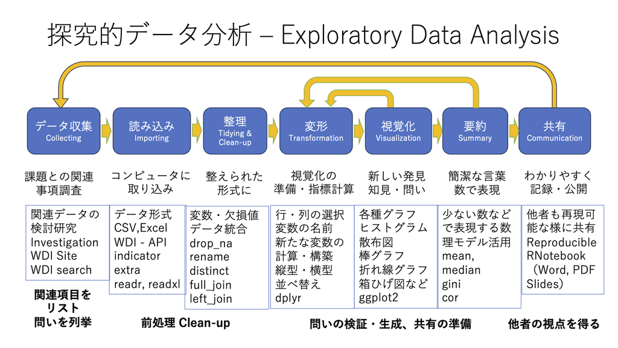

## 人口に関する課題・少子高齢化

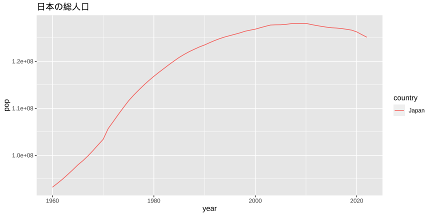

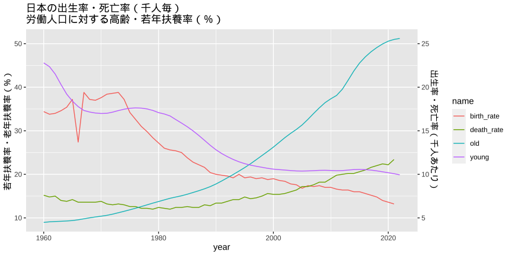

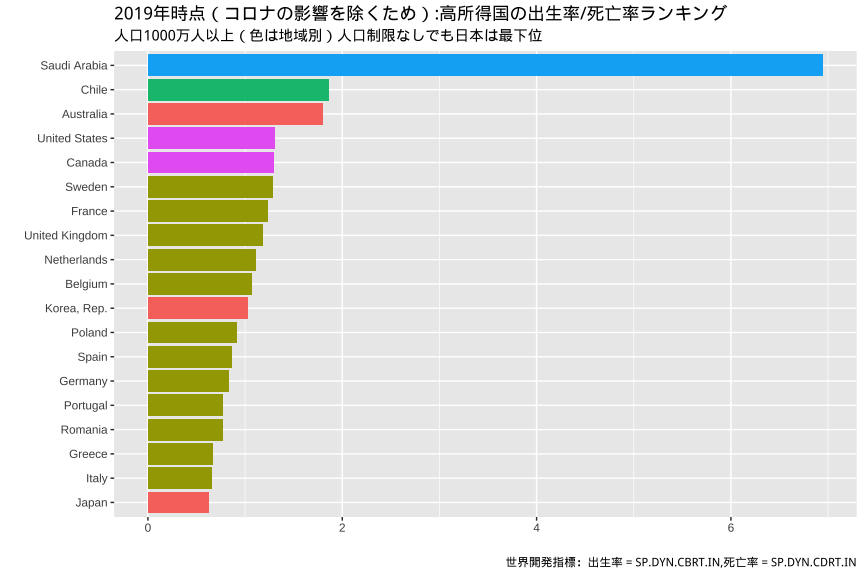

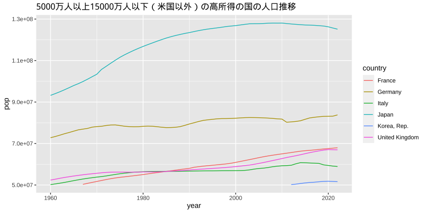

**気づいたこと・疑問点**

-日本とイタリア以外は、みな増加している

## 「日本ごと」を「世界ごと」としてとらえる

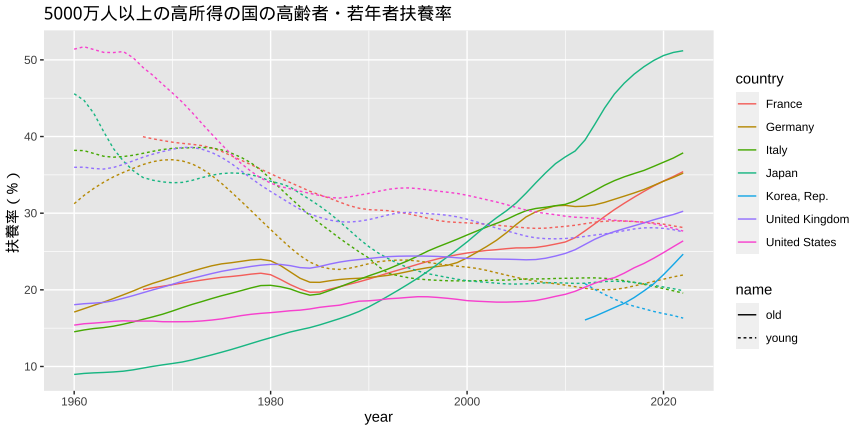

- さまざまなことが見えてきませんか。

## GINI 係数と、絶対的貧困

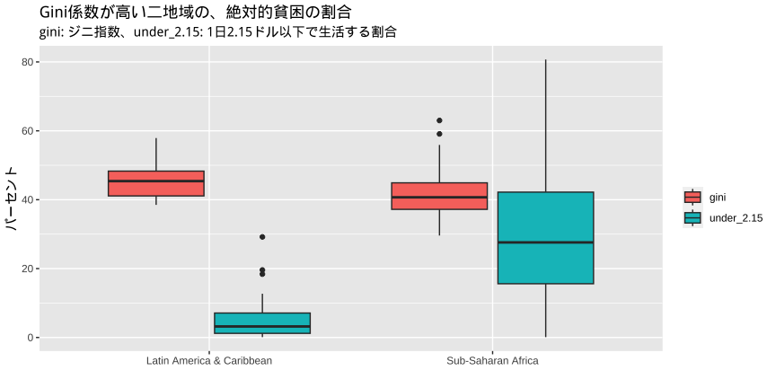

- 同じように、ジニ指数は高く、貧富の差は大きいようですが、絶対的貧困の人の割合はかなり異なるようです。指標の理解が大切です。

### 箱ひげ図 (Boxplots)・ハズレ値 (Outliers)

| country | year | name | value | region |
| --- | --- | --- | --- | --- |
| Haiti | 2012 | under_2.15 | 29.2 | Latin America & Caribbean |
| Belize | 1999 | under_2.15 | 19.6 | Latin America & Caribbean |
| Suriname | 1999 | under_2.15 | 18.4 | Latin America & Caribbean |
| South Africa | 2014 | gini | 63.0 | Sub-Saharan Africa |
| Namibia | 2015 | gini | 59.1 | Sub-Saharan Africa |

### **外れ値に注意**：アンナ・カレーニナ原理（Anna Karenina Principle (AKP）)

- 「幸福な家庭は全て互いに似通っているが、不幸な家庭はどこもその趣が異なっている」（トルストイ）
- All happy families are all alike; each unhappy family is unhappy in its own way
- 外れ値をとる背景には、さまざまな背景があり、それを個別に分析することで、その指標に関して、特別な値をとる理由を垣間見ることができる場合がある。
- 健康ではない理由はさまざま。病気とひとくくりにすると見えないものが多い。

## 二酸化炭素排出量と電力

|  | co2pcap | forest | renewable | fossil | nuclear |
| --- | --- | --- | --- | --- | --- |
| co2pcap | 1.00000000 | -0.1548686 | -0.3902420 | 0.3056159 | 0.09178764 |
| forest | -0.15486856 | 1.0000000 | 0.3316376 | -0.3664743 | 0.10163594 |
| renewable | -0.39024200 | 0.3316376 | 1.0000000 | -0.8824027 | -0.11973317 |
| fossil | 0.30561592 | -0.3664743 | -0.8824027 | 1.0000000 | -0.28368597 |
| nuclear | 0.09178764 | 0.1016359 | -0.1197332 | -0.2836860 | 1.00000000 |

### 散布図: 相関は因果にあらず

Correlation is not causation!

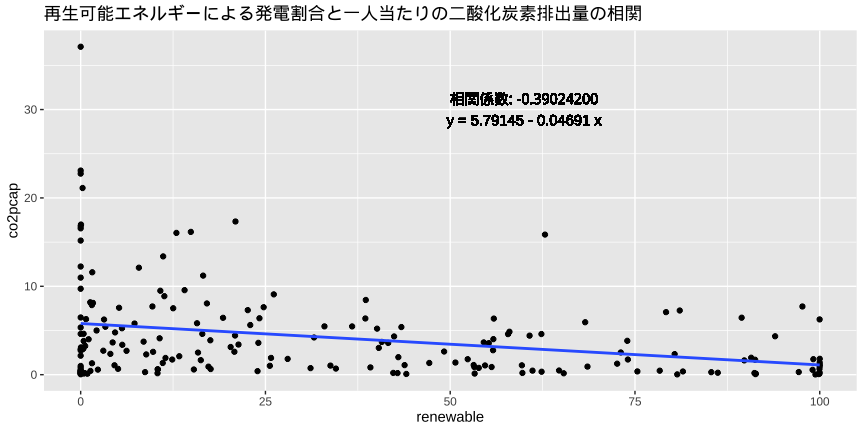

### 近似（回帰）直線の方程式

Regression Line: estimate の値が、y 切片（y-intercept）と、x （renewable）の係数（直線の傾き:slope of the line）

```r
df_environment |> filter(!(iso2c %in% REGION)) |> filter(year == 2014) |>
  drop_na(renewable, co2pcap) |> lm(co2pcap ~ renewable, data = _) |> broom::tidy()
```

| term | estimate | std.error | statistic | p.value |
| --- | --- | --- | --- | --- |
| (Intercept) | 5.79145040 | 0.50818451 | 11.396354 | 3.077482e-23 |
| renewable | -0.04690588 | 0.01078079 | -4.350876 | 2.216348e-05 |

## 世界開発指標（World Deveopment Indicators）

- WDI の指標数: 1,486、最大217カ国、79地域のデータ
- 国および年によっては、いくつかの指標のデータが提供されていません。

### 質問

- アメリカ合衆国、日本、中国、ロシア で、世界銀行に、国別データを一番たくさん、提供している国は？
- アメリカ合衆国、日本、中国、ロシア で、世界銀行に、国別データを一番少ししか、提供していない国は？

### 国別データの提供数

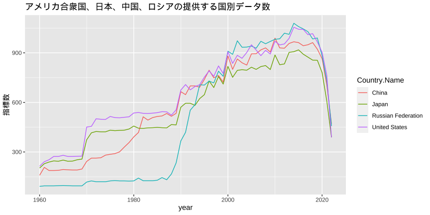

ベルリンの壁崩壊 1989年、ソビエト社会主義共和国連邦が崩壊したのは、1988年から1991年、1991年東西ドイツ統合

### 2015年の国別データの提供数

| year | Country.Name | Country.Code | n |
| --- | --- | --- | --- |
| 2015 | Russian Federation | RUS | 1059 |
| 2015 | United States | USA | 1043 |
| 2015 | India | IND | 1039 |
| 2015 | Germany | DEU | 1024 |
| 2015 | Italy | ITA | 1007 |
| 2015 | France | FRA | 993 |
| 2015 | United Kingdom | GBR | 974 |
| 2015 | China | CHN | 962 |
| 2015 | Japan | JPN | 918 |

**オープンデータを活用**し、情報の透明性を高くしていきましょう。

## おわりに

- **「日本ごと・世界ごと・自分ごと」 「自分ごと・世界ごと・日本ごと」**
  - 自分が生きている社会の課題 vs 普遍的な人間の課題 vs 自分や個人の課題
  - 自分や個人の課題 vs 普遍的な人間の課題 vs 自分が生きている社会の課題

**オープンデータは、通常は困難な「世界ごと」として課題を相対化、普遍化する。**

- **今だけ、金だけ、自分だけ**（単純化バイアス）にとらわれない生き方
  - 遺伝子的情報の中に自己防衛本能として書き込まれているかもしれない
  - 思考しているその時、見えやすい価値、自分の経験だけに縛られずより広い視点へ

**制約条件を弱めることで、より（個別の課題だけではない）普遍的な、継続性もある、解決方法の緒（いとぐち clue）がみつかることがある**

## おわりに（つづき）：AI とどう付き合っていくか

- **探究的データ分析**：得られた結論に満足せず、探求し続けることを厭わないで
  - 分断ではなく、公開・共有・議論・協働によって、他者の視点をたいせつに
  - 課題は相互に複雑に関係し合っているが、データ（情報）も膨大にある。
  - 特定の行動の決断が正しいか間違っているかで争うより、行動しながら、その影響を図りながら、修正していくことがたいせつ。施策の影響は、実行してみないとわからない部分もある。
- AI の最大の強みは、**学び続けること**
  - AI の影響が大きくなっていく時代に、AIと上手に付き合うには、AI の思考方法（データサイエンス）を自分も経験し、コミュニケーションしましょう。
  - さまざまなひとへの影響を、丁寧に測定し、AI とともに考えましょう。

**ありがとうございました**